### Predation and growth of Lythrum salicaria along a latitudinal gradient as an invasive species in North America.

### By : Shannon Mawhinney & David Foubert

### June 10th, 2018

**Abstract**

Lythrum salicaria is an invasive wetland plant in north america that has evolved localized phenotypic differences, the plant is preyed upon by several types of beetles. Common garden studies are used to examine the difference in resistance and tolerance to herbivory in the different climatic plants. Previous common garden experiments have show the phenotypic differences of L.salicaria along latitudinal gradients, we are testing the hypothesis that latitudinal difference in L. salicaria can also be attributed to variation in herbivory. Using a previously arranged common garden we measured height, stem count and whether damage was present or absent. This study found that the mid latitude L.salicaria species in the mid latitude garden had the highest rates of herbivory and were positively correlated with height. This is thought to be because of a home team advantage that Galerucella calmariensis have evolved with the plants of this area evolving alongside the L.salicaria that they feed on.

**Introduction** Invasive specie have become an increasing area of interest in science over the last two decades, as climate change is now evident in nature around us people want to know how that will change ecosystems and what that means for native specie, especially as new species are introduced. It is being seen across the world that as temperatures rise many species, from plants to animals, are expanding their range north or south from the equator, one of these is Lythrum salicaria (purple loosestrife). A plant native to europe, asia and western africa, that is found in low lying marshy areas or along lake shores and river banks (Grey-Wilson, 1989), it was introduced to north america in the 1800s and has evolved local adaptations at varying latitudes throughout north america (colautti & barrett, 2013). The effects of this invasion are not entirely understood at a local or national scale, in order to better understand the local adaption of invasive species common garden experiments can be used at latitudinal or altitudinal clines to observe native and non-native triat differences (colautti & barrett, 2013).

Local adaptations are generally beneficial when in the home range for the adaptation but can have fitness trade-offs when moved to another populations latitude, considering these adaptations and their impacts on Lythrum salicaria, we are investigating whether latitudinal adaptations and plant height are positively correlated to higher predation by Galerucella calmariensis. The phenotype of the plants and their flower morphology has been known to affect the prevalence of herbivory (Feeny, 1970) but also affect other plant - environment interactions. With respect to the Tropical Defense Hypothesis(Rasmann & Agrawal, 2011), in which plants closer to the equator undergo higher predation and therefore have higher resistance to damage, this is likely relative to the number of predators that are available in the area, longer warm seasons allow for larger and more abundant predators. With this in mind we expect to see the most pedation on the mid latitude plants as this is the range the experiment is occuring in and the herbivores are most adapted to the plants of their region.

Here, we are examining the differences in herbivory in a latitudinal variety of plants from north america in a single common garden, north of Kingston, Ontario. Using the height, stem counts and presence or absence of herbivory damage of the plants to examine the differences. We then related this information back to the plants original location and examined the variation in herbivory damage. Specifically we examined whether latitude origin affected the amount of herbivory damage and whether size played a role in herbivory damage.

**Materials and Methods**

*Specimen collection*

Lythrum salicaria plants were set up as an experiment on the introduction of a biocontrol by Eugene in 2017. The plants were grown and harvested from a common garden at Queen’s University Biological Station (QUBS) in 2017. These plants were grown from seed in a greenhouse in May and June 2017, with up to 12 replicates from each maternal seed family. Families were either sourced from an experiment on Bracken Tract at QUBS where natural herbivory was manipulated during the summer of 2016, or from a series of populations along a geographic transect through Ontario, New York State, Pennsylvania, and Virginia.(Eugene et al, 2017) We performed measurements on Lythrum salicaria plants in the common garden the following year, on May 20th 2018.

The plants are grouped in transects by the experiment they were sourced from, either the natural herbivory manipulation or the latitudinal gradient study, identified as M or E respectively. The plants are randomly distributed between all the corresponding blocks, as to reduce the random effect of the family and location of collection. The plants that were part of the natural herbivory manipulation experiment, conducted by Muzz(Muzz et al, 2016), were sprayed several times in the spring of 2016 with DeltaGard SC insecticide by Bayer (active ingredient: deltamethrin) to reduce herbivory establishment.

Beetles of the Galerucella family that originate from the native habitat of the Lythrum salicaria were introduced to study them as a biocontrol. The beatles specialize in using as their unique food source were introduced as a biocontrol. The beatles spend their entire life cycle on the plants, consuming the leaves as adults and the apical meristem as larvae.

*Computational manipulation*

The raw data that we collected from the common garden in 2018 was entered in separate csv files and merged using Openrefine version 2.8, saved as PL_complete.csv. The data was then cleaned to fit the values to a uniform style. The manipulations by which the data was transformed are available as PL_refining.JSON. All other and following analysis and manipulation was done with R in Rstudio version 1.1.423 Data was grouped by Population and Origin, and the means calculated for associated variables using ddply() function from dplyr package version 0.7.4

*Statistical analysis*

A non-metric multidimensional scaling (NMDS) was performed on the data grouped as populations using the metaMDS() function from vegan version 2.5-2 Linear models were fit to our data using the lm() function from the stats package version 3.4.3 Anovas were performed to test the accuracy of the linear models being fitted to our data and to establish how significant the variables are to the models. Also used to test significance of RDA and its variables. Anovas were performed using the anova() function from the stats package version 3.4.3. The plotting of data was accomplished using qplot() function from the ggplot2 package version 2.2.1.

Data and supplemental material: Data and code used for analysis are publicly available online at https://github.com/superwhat1/fieldbio.git. Data manipulation in R of the data that was output of OpenRefine is available in the Project_Data.R file. All visualizations, including those presented here in and supplemental tables and figures are available in the Final_Project_Visualization.Rmd file.

**Results**

1. Stem.length is significantly positively correlated to Damage
2. Stem.Count is significantly positively correlated to Damage
3. Previous years vegetative weight is significantly correlated to damage modeled alone
4. Previous years root weight is slightly significantly correlated to Damage

Data was grouped as populations to be able to test relations to damage. The grouped data provided mean damage values that were not 0 or 1, facilitating/making possible the fitting of data and plotting(Table 1).

```r
POP_mean
```

| POP | LAT_mean | Dam_mean | SL_mean | SC_mean | VEGWT_mean | RWT_mean | PREV_mean | Origin |
| --- | --- | --- | --- | --- | --- | --- | --- | --- |
| 1 | 38.82350 | 0.2878788 | 11.40530 | 5.401515 | 11.948311 | 0.26790152 | 12.216212 | 3_South |
| 2 | 38.79660 | 0.1735537 | 10.99174 | 6.148760 | 8.644876 | 0.09319835 | 8.738074 | 3_South |
| 3 | 40.23327 | 0.2315789 | 13.55579 | 8.189474 | 13.036221 | 0.32024211 | 13.356463 | 3_South |
| 4 | 40.06813 | 0.4000000 | 14.97500 | 9.625000 | 13.583250 | 0.62447500 | 14.207725 | 3_South |
| 5 | 41.42692 | 0.3000000 | 13.67143 | 5.242857 | 10.460757 | 0.62467143 | 11.085429 | 3_South |
| 6 | 41.57154 | 0.3185841 | 12.07522 | 5.876106 | 11.593541 | 0.40905405 | 12.002595 | 3_South |
| 8 | 41.97527 | 0.2880000 | 12.67600 | 7.292000 | 12.949720 | 0.59086400 | 13.540584 | 2_Mid |
| 9 | 42.79109 | 0.3561644 | 13.16438 | 7.041096 | 7.299819 | 0.32073611 | 7.620556 | 2_Mid |
| 10 | 43.69717 | 0.3587786 | 15.14122 | 6.343511 | 13.529008 | 0.78701527 | 14.316023 | 2_Mid |
| 11 | 43.28958 | 0.3636364 | 14.34848 | 6.363636 | 12.837405 | 0.36201527 | 13.199420 | 2_Mid |

[output cut: 10 more lines]

**Table1. Latitudinal gradient experiment data averaged per population**

The data for the experiment on latitudinal gradients by Eugene was pulled from the main dataset and the grouped by population of collection. The variables were then grouped and averaged by population.

*Damage along latitudinal gradient*

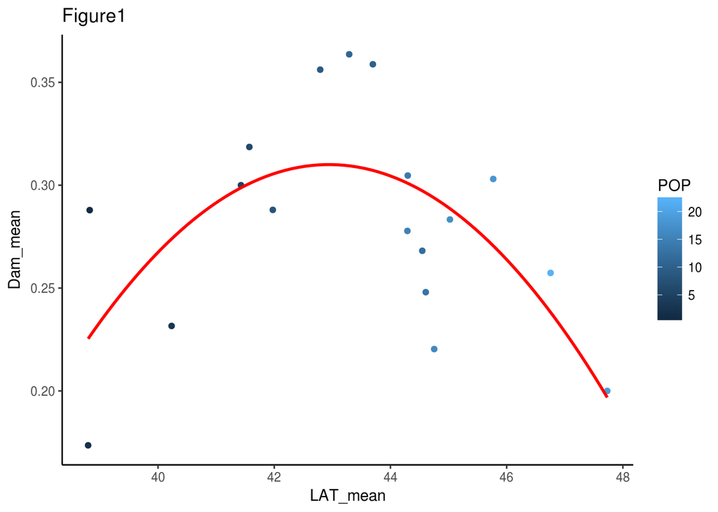

```r
qplot(x=LAT_mean, y=Dam_mean, data=POP_copy, colour=POP, main="Figure1") +theme_classic() +
  geom_smooth(mapping=aes(x=LAT_mean, y=predict(mod8)),data=POP_copy,colour='red') +
  theme_classic()
```

**Figure 1. Predation damage of Lythrum salicaria leaves plotted against the latitude of collection.**

Mean latitude plotted against mean damage of populations, data used to plot is from POP_mean. The values for the point with a latitude of 48.10384 was removed due to being an outlier. (R^2adj=0.2292, R^2=0.3148, P=0.04856) polynomial correlation of the second degree and significant. Two values were omitted from the plot and the model as being outliers. There may have been errors in measurements or data input, as the data was collected by us in its entirety. There is polynomial distribution of the data with apex at the mid latitudes.

*Plant growth along latitudinal gradient*

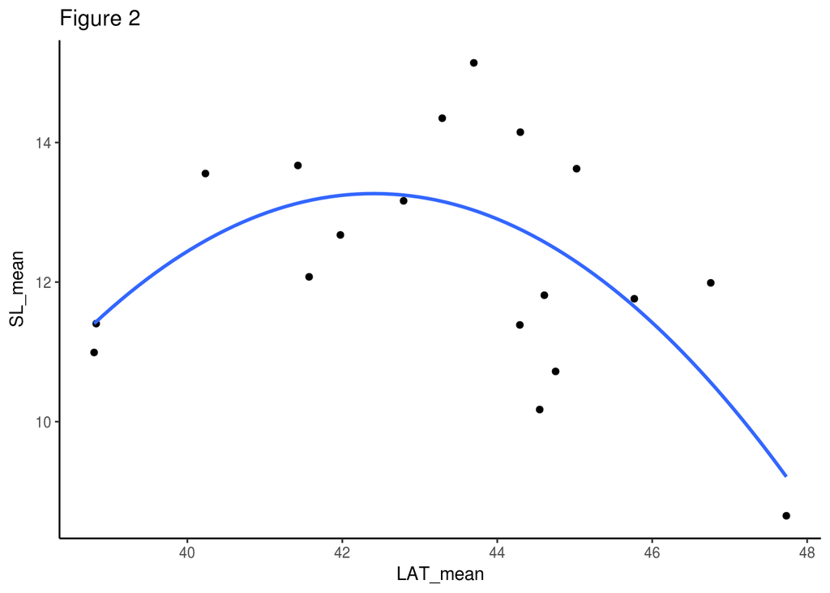

```r
qplot( x=LAT_mean, y=SL_mean,data=POP_copy, main="Figure 2") +geom_smooth(mapping=aes(x=LAT_mean,y=predict(mod9)) ) +
  theme_classic()
```

**Figure 2. Length of Lythrum salicaria stem plotted against latitude of collection.**

Mean latitude plotted against mean stem length of populations, data used for plotting are from POP_mean. The values for the point with a latitude of 48.10384 was removed due to being an outlier. (R^2adj=0.3589, R^2=0.4301, P=0.01113) with the outlier the p value of the model is p=0.8026. There is significant polynomial distribution of data.

*Plant size and damage*

```r
mod11 = lm(SL_mean~PREV_mean,data=POP_mean)
summary(mod11)
```

```
##
## Call:
## lm(formula = SL_mean ~ PREV_mean, data = POP_mean)
##
## Residuals:
##     Min      1Q  Median      3Q     Max
## -2.0636 -1.1977 -0.1224  0.9595  4.5121
##
## Coefficients:
##             Estimate Std. Error t value Pr(>|t|)
## (Intercept)   8.7080     1.5267   5.704 2.08e-05 ***
## PREV_mean     0.3758     0.1422   2.643   0.0165 *
## ---
## Signif. codes:  0 '***' 0.001 '**' 0.01 '*' 0.05 '.' 0.1 ' ' 1
##
## Residual standard error: 1.635 on 18 degrees of freedom
## Multiple R-squared:  0.2796, Adjusted R-squared:  0.2396
## F-statistic: 6.987 on 1 and 18 DF,  p-value: 0.01652
```

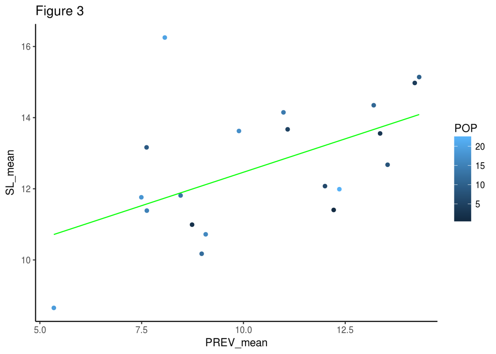

```r
qplot( y=SL_mean, x=PREV_mean,data=POP_mean, colour=POP, main="Figure 3") +geom_line(mapping=aes(x=PREV_mean,y=predict(mod11)), colour="green" ) +
  theme_classic()
```

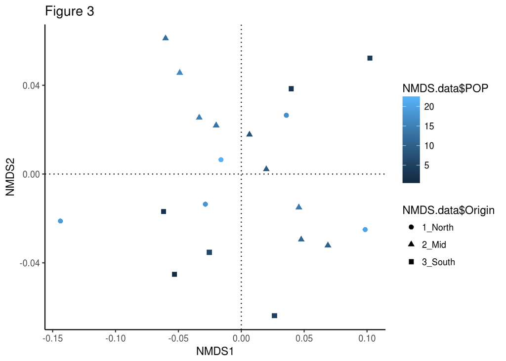

```r
ggplot(data = NMDS.data, aes(y = NMDS2, x = NMDS1))+
    geom_point( aes(colour = NMDS.data$POP,shape = NMDS.data$Origin), size = 2) +
    geom_hline(yintercept=0, linetype="dotted") +
    geom_vline(xintercept=0, linetype="dotted") +
    ggtitle("Figure 3")+
      theme_classic()
```

**Figure 4. NMDS of Lythrum salicaria populations.**

**Discussion**

*Damage along latitudinal gradient*

[output not shown]

*Plant growth along latitudinal gradient*

[output not shown]

*Plant size and damage*

[output not shown]

There is a possibility that the L. salicaria plants produce compounds that are a deterrent or even harmful to the beetles in the early stage of growth. These compounds might only be produced in the early stages, to protect itself against damage that could be fatal and impede the plants growth severely. The genes responsible for the production of these compounds may be turned off in place of others, as is the case for other genes(Yihan Wu & Robert I. Colautti, 2018). After the plants have reached a certain size the compounds are no longer needed to protect it against critical damage, as it is unlikely the beatles will be able to inflict enough damage to overcome the speed of growth. It would be interesting to monitor the growth over time in an entire season to see if this is the case. The beatles and the Lythrum are most likely engaged in an arms race. Each species attempting to get an edge on the other, plants to protect themselves against the beetles and the later to counter/resist the compounds produced by the plants. The plants might need to trade off producing large amounts of deterring compounds for the necessity to grow and produce seeds to stay competitive against other plants.

*Biocontrol over time*

```
As Lythrum salicaria is an invasive plant that is on management lists nationally it is important to understand the impacts of herbivory as a control agent. This study did not go into depth on the percent damage of plants of varying latitudes and if this actually affected the plants fitness over time, this is an interesting area of study for the future. Some preliminary research has been conducted in other wild or test  L. salicaria populations. They released G. calmariensis and G. pusilla  36 sites throughout New York where they then measured the stand area of the plants , plant density and plant height. They measured at the initial release in 1994 and than again in 2004(Grevstad,2006). The study found that plant height had been significantly impacted but the stand area of the population remained the same (Grevstad,2006). They examined the presence or absence of the beetles at the sites and monitored population size to see if that was a factor in controlling the populations but did not find any significance(Grevstad,2006).  This would be an interesting area to study further as biocontrols can be effective if the right settings are provided. The differences in herbivory across North American latitudes and how they are causing genetic changes in these plants are areas of study that could be paired with biocontrol studies to try and manage this invasive species.
```

**Conclusion**

In conclusion the study of this mid latitude garden has lead to the conclusion that latitudinal changes in Lythrum salicaria affects their fitness when transported to other latitudes. As well as having smaller plants that are less productive, the herbivores of this area tend to select their native plants over those from other latitudes. This may be due to plants that have evolved to bloom at different time of the year based on their original latitude, the growth/ breeding season of the herbivor at this latitude or the directional selection pressures of the herbivores on the plants that have cause resistance or tolerance of the herbivory for each individual latitude. Further studies should be taken to examine percent damage of each latitude group at each of the common gardens along the latitude stretch to further understand the effect of the herbivor on the fitness of the plant. Studies may also undertaken to see the population size of G. calmariensis and G. pusilla needed to effectively control the populations and the potential risks to surrounding environments and other similar species.

**References**

Colautti, R. I., & Barrett, S. C. (2013). Rapid Adaptation to Climate Facilitates Range Expansion of an Invasive Plant. Science,342(6156), 364-366. doi:10.1126/science.1242121

Colautti, R. I., Maron, J. L., & Barrett, S. C. (2009). Common garden comparisons of native and introduced plant populations: Latitudinal clines can obscure evolutionary inferences. Evolutionary Applications,2(2), 187-199. doi:10.1111/j.1752-4571.2008.00053.x

Grevstad, F. S. (2006). Ten-year impacts of the biological control agents Galerucella pusilla and G. calmariensis (Coleoptera: Chrysomelidae) on purple loosestrife (Lythrum salicaria) in Central New York State. Biological Control,39(1), 1-8. doi:10.1016/j.biocontrol.2006.03.007

Grey-Wilson, C. (1989). HE ILLUSTRATED FLORA OF BRITAIN AND NORTHERN EUROPE. London: Lubrecht & Cramer. Doi:0340401702

Lehndal, L., & Agren, J. (2015). Latitudinal variation in resistance and tolerance to herbivory in the perennial herb Lythrum salicaria is related to intensity of herbivory and plant phenology. Evolutionary Biology,28(3).

Olsson, K., & Ågren, J. (2002). Latitudinal population differentiation in phenology, life history and flower morphology in the perennial herb Lythrum salicaria. Journal of Evolutionary Biology,15(6), 983-996. doi:10.1046/j.1420-9101.2002.00457.x

Yihan Wu & Robert I. Colautti, (2018). Rob Field Course Tutorial. https://colauttilab.github.io/NGS/DifferentialExpression.html